# Juan Reyes, Ilya Schneider, Francesco de Luca

## Modeling

First, we make a basic decision tree to understand which variables were the most useful in predicting poverty in our data frame. We excluded from our model the other measure of poverty (`poverty`), as well as household income, from the model, since both of those are directly predictive of poverty, and are thus not useful to us.

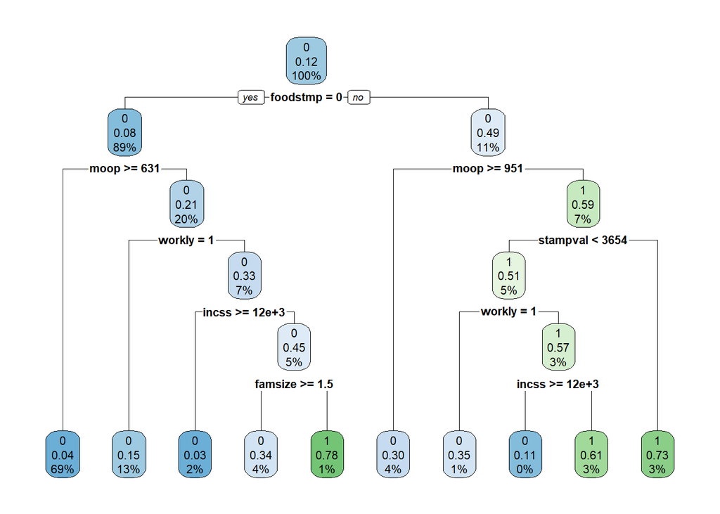

```r
#Creating data frame for the analysis
weighted_cps <- as_survey_design(cps_svy, weights = asecwt) %>%
  select(-poverty, -hhincome)
weighted_cps <- as.data.frame(weighted_cps)

weighted_cps_models <- weighted_cps %>%
  drop_na(offpov) %>%
  mutate(offpov = as.factor(offpov)) %>%
  select(-year) %>%
  mutate_at(vars(immigrant,
                 pubhous,
                 foodstmp,
                 sex,
                 vetstat,
                 labforce,
                 diffany,
                 himcarely,
                 phinsur,
                 anycovnw,
                 kidcneed,
                 workly),
            list(~ as.factor(.))
  )

set.seed(20211101)

#Creating a split object:
weighted_cps_split <- initial_split(data = weighted_cps_models, prop = 0.8)

#Creating the training and testing data:
weighted_cps_train <- training(x = weighted_cps_split)
weighted_cps_test <- testing(x = weighted_cps_split)

#Creating a recipe:
cart_rec <-
  recipe(formula = offpov ~ ., data = weighted_cps_train)

#Creating a cart model object:
cart_mod <-
  decision_tree() %>%
  set_engine(engine = "rpart") %>%
  set_mode(mode = "classification")
cart_wf <- workflow() %>%
  add_recipe(cart_rec) %>%
  add_model(cart_mod)

#Fitting the model:
cart_fit <- cart_wf %>%
  fit(data = weighted_cps_train)

# Creating a tree:
rpart.plot::rpart.plot(x = cart_fit$fit$fit$fit, roundint=FALSE)
```

```r
# Predicting the predicted class and the predicted probability of each class:
predictions <- bind_cols(
  weighted_cps_test,
  predict(object = cart_fit, new_data = weighted_cps_test),
  predict(object = cart_fit, new_data = weighted_cps_test, type = "prob")
)
select(predictions, offpov, starts_with(".pred"))
```

[output not shown]

The next step is to construct a random forest:

First we create the data frame we will use for our modeling, filtering out NA values from offpov, and turning variables into factors. We then set the seed and split the data into a test set and a training set. Next we created a recipe for the random forest model, turning categorical variables into dummy variables. Lastly, we created a random forest model setting the engine to ranger and mode to classification. After creating a workflow, we create a grid for parameters and then attempt to execute it. At this point, our model fails to run any further. Unfortunately, we were unable to calculate the ROC_AUC or accuracy of our model for this reason. If successful, the random forest model would have allowed us to isolate the variables of greatest importance for predicting poverty at an individual level.

```r
# Creating dataframe for random forest model
rf_model_cps_2018 <- weighted_cps_2018 %>%
  filter(!is.na(offpov)) %>%
 mutate(offpov = as.factor(offpov)) %>% # Here we make our y variable a factor variable
 select (- year  , - county , -poverty , -hhincome , -asecwt , -stampval , yrimmig , moop) %>% # We remove variables we don't want to include as predictors
   mutate_at(vars(metro, statefip, pubhous, vetstat, empstat, labforce, occ, ind, classwkr, uhrsworkt, educ, diffany, occly, indly, classwly, workly, incint, migrate1, himcarely, kidcneed, union), list(~ as.factor(.)))
```

```r
# Set seed so model is consistent
set.seed(12122022)
# Split data frame into training and testing data
split <- initial_split(rf_model_cps_2018)

rf_cps_2018_train <- remove_val_labels(training(split))
rf__cps_2018_test <- remove_val_labels(testing(split))

# Set up 5 folds
folds <- vfold_cv(data = rf_cps_2018_train, v = 5)

# Create a recipe for random forest model

rf_rec <-
  recipe(offpov ~ ., data = rf_cps_2018_train) %>%
  step_dummy(metro, statefip, pubhous, vetstat, empstat, labforce, occ, ind, classwkr, uhrsworkt, educ, diffany, occly, indly, classwly, workly, incint, migrate1, himcarely, kidcneed, union) %>% #Turn select categorical variables into dummies
  step_center(all_numeric_predictors()) %>% # this centers predictors
  step_scale(all_numeric_predictors()) %>% # this scales predictors
  step_nzv(all_numeric_predictors()) # this drops near zero variance predictors
```

```r
# Making a random forest model
rf_model <- rand_forest(mtry = 10, min_n = tune(), trees = 100) %>%
  set_engine("ranger", importance = "impurity") %>%
  set_mode("classification")

# Create a workflow
rf_workflow <-
  workflow() %>%
  add_model(rf_model) %>%
  add_recipe(rf_rec)

# Create a grid of the parameters
rf_grid <- grid_regular(
  min_n(range = c(2, 8)),
  levels = 4)

# Execute hyperparameter tuning using the grid and the cross_validation folds - here is where the code takes too long to run
#rf_cv <- tune_grid(rf_workflow,
                   #resamples = folds,
                   #grid = rf_grid,
                   #metrics = metric_set(roc_auc))

# Calculate ROC_AUC and accuracy
#collect_metrics(rf_cv, summarize = TRUE) %>%
  #filter(.metric == "roc_auc")

# Select the best model based on roc_auc
#rf_best_model <- rf_cv %>%
  #select_best(metric = "roc_auc")

# Finalize model
#rf_final_model <- finalize_model(rf_model, rf_best_model)
# Evaluate variable importance
#rf_last_fit %>%
  #extract_fit_parsnip() %>%
  #vip::vip(num_features = 15)
#rf_predictions <- bind_cols(rf__cps_2018_test,
                            #predict(object = rf_last_fit, new_data = rf__cps_2018_test),
                            #predict(object = rf_last_fit, new_data = rf__cps_2018_test, type = "prob"))

# To evaluate the model calculate...
# Confusion matrix
#conf_mat(data = rf_predictions,
         #truth = offpov,
         #estimate = .pred_class)
# Accuracy
#accuracy(data = rf_predictions,
          #truth = offpov,
          #estimate = .pred_class)
# ROC_AUC metric
#roc_auc(data = rf_predictions,
     #truth = employed,
     #estimate = .pred_0)
```

The next attempted model was k nearest neighbors:

In the KNN model, we attempted to predict the value of `offpov` with the predictive variables in the weighted CPS data frame. We decided to tune the number of neighbors based on the best model that would have resulted from the fit into the folds we created. Unfortunately, we were unable to fit the model because of an error we kept incurring into. The error message appeared whenever we tried to fit the model into the folds we created, and didn’t disappear no matter how we tweaked the data or the steps in the model’s recipe.

```r
#Creating folds:
#folds <- vfold_cv(data = weighted_cps_train, v = 5)
#Creating a recipe object:
#weighted_cps_rec <-
  #recipe(formula = offpov ~ ., data = weighted_cps_train) %>%
  #step_dummy(immigrant,
             #pubhous,
             #foodstmp,
             #sex,
             #etstat,
             #labforce,
             #diffany,
             #himcaidly,
             #himcarely,
             #phinsur,
             #anycovnw,
             #kidcneed,
             #workly)
  #step_center(all_numeric_predictors()) %>%
  #step_scale(all_numeric_predictors()) %>%
  #step_nzv(all_numeric_predictors()) %>%
  #step_impute_knn(all_predictors()) %>%
  #step_other()

# Creating a KNN model with hyper parameter tuning:
# Creating a KNN model specification:
#weighted_cps_knn_mod <-
  #nearest_neighbor(neighbors = tune()) %>%
  #set_engine(engine = "kknn") %>%
  #set_mode(mode = "classification")
# Creating a workflow:
#weighted_cps_knn_workflow <-
  #workflow() %>%
  #add_model(spec = weighted_cps_knn_mod) %>%
  #add_recipe(recipe = weighted_cps_rec)
# Creating a tuning grid:
#weighted_cps_knn_grid <- grid_regular(neighbors(range = c(1, 15)), levels = 2)
# Estimating models with re-sampling for each row in the tuning grid:
#weighted_cps_knn_res <- weighted_cps_knn_workflow %>%
  #tune_grid(resamples = folds,
            #grid = weighted_cps_knn_grid,
            #control = control_grid(save_pred = TRUE),
            #metrics = metric_set(accuracy))
```

Finally, our last intended model was a LASSO model:

The process we went through for this model was similar as for the others. We cleaned the data for this specific model, which included turning all the NAs into 0s. We then went through the process of splitting the data, creating a recipe, making a model, and a workflow, and attempting to apply the new model to our data. Alas, we ran into an issue here as well. This time, however, we managed to get the RMSE associated with each fold. No amount of fiddling with the recipe or cleaning of the data resulted in a successful model.

```r
#Preparing the data

#Deleting year
weighted_cps_2018_lasso <- weighted_cps_2018 %>%
  select(-year, -asecwt)

#Turning NAs into 0s
weighted_cps_2018_lasso[is.na(weighted_cps_2018_lasso)] <- 0

set.seed(12122022)
split <- initial_split(weighted_cps_2018_lasso)

weighted_cps_2018_train <- training(split)
weighted_cps_2018_test <- testing(split)

#Set up resampling
folds1 <- vfold_cv(weighted_cps_2018_train, v = 5)

#Create a tuning grid for lasso regularization
lasso_grid <- grid_regular(penalty(), levels = 10)

#Creating a recipe
weighted_cps_2018_rec <- recipe(offpov ~ ., data = weighted_cps_2018_train) %>%
  step_dummy(all_nominal(), -all_outcomes()) %>%
  step_center(all_predictors()) %>% # center predictors
  step_scale(all_predictors()) %>% # scale predictors
  step_nzv(all_predictors()) # drop near zero variance for all predictors
  #step_other(all_predictors())  # collapse low-frequency categories


#See the engineered training data
bake(prep(weighted_cps_2018_rec, training = weighted_cps_2018_train), new_data = weighted_cps_2018_train)
```

```
# A tibble: 135,063 × 35
   statefip  metro ownershp hhinc…¹ foods…² stampmo     age    sex   race  marst
      <dbl>  <dbl>    <dbl>   <dbl>   <dbl>   <dbl>   <dbl>  <dbl>  <dbl>  <dbl>
 1   -0.165  0.486   -0.691  -0.296  -0.351  -0.334 -1.53   -1.03  -0.410  0.971
 2    1.24  -0.524   -0.691  -0.312  -0.351  -0.334  0.614  -1.03  -0.410 -1.18
 3   -0.654 -0.524    1.45   -0.874   2.85    3.18   1.45    0.970  0.158  0.971
 4   -0.165  0.486    1.45   -0.139  -0.351  -0.334  0.0450  0.970 -0.410  0.112
 5    1.18   0.486   -0.691  -0.618  -0.351  -0.334  0.351  -1.03   0.158  0.971
 6    0.692  0.486   -0.691   0.954  -0.351  -0.334  0.351  -1.03  -0.410 -1.18
 7    1.06   1.49    -0.691  -0.598  -0.351  -0.334  1.31    0.970  0.158  0.541
 8    0.692  0.486   -0.691   0.496  -0.351  -0.334  0.0450 -1.03  -0.410 -1.18
 9    1.24   0.486   -0.691  -0.930  -0.351  -0.334  1.05    0.970  2.72   0.112
10   -1.33   0.486   -0.691   0.690  -0.351  -0.334  0.133   0.970 -0.410 -1.18
# … with 135,053 more rows, 25 more variables: vetstat <dbl>, famsize <dbl>,
#   nchild <dbl>, nchlt5 <dbl>, citizen <dbl>, hispan <dbl>, empstat <dbl>,
#   labforce <dbl>, ind <dbl>, classwkr <dbl>, uhrsworkt <dbl>, educ <dbl>,
#   diffany <dbl>, indly <dbl>, classwly <dbl>, workly <dbl>, poverty <dbl>,
#   migrate1 <dbl>, himcarely <dbl>, phinsur <dbl>, moop <dbl>, anycovnw <dbl>,
#   union <dbl>, immigrant <dbl>, offpov <dbl>, and abbreviated variable names
#   ¹hhincome, ²foodstmp
```

```r
#Create a model
lasso_mod <- linear_reg(penalty = tune(), mixture = 1) %>%
  set_engine("glmnet") %>%
  set_mode("regression")

#Create a workflow
lasso_wf <- workflow() %>%
  add_recipe(weighted_cps_2018_rec) %>%
  add_model(lasso_mod)

#Perform hyperparameter tuning
lasso_cv <- lasso_wf %>%
  fit(weighted_cps_2018_train) %>%
  tune_grid(resamples = folds1,grid = lasso_grid)
```

[output not shown]

[output not shown]

[output not shown]

[output not shown]

[output not shown]

```r
collect_metrics(lasso_cv, summarize = FALSE)
```

```
# A tibble: 100 × 6
   id         penalty .metric .estimator .estimate .config
   <chr>        <dbl> <chr>   <chr>          <dbl> <chr>
 1 Fold1 0.0000000001 rmse    standard      0.0540 Preprocessor1_Model01
 2 Fold1 0.0000000001 rsq     standard      0.973  Preprocessor1_Model01
 3 Fold2 0.0000000001 rmse    standard      0.0568 Preprocessor1_Model01
 4 Fold2 0.0000000001 rsq     standard      0.970  Preprocessor1_Model01
 5 Fold3 0.0000000001 rmse    standard      0.0561 Preprocessor1_Model01
 6 Fold3 0.0000000001 rsq     standard      0.971  Preprocessor1_Model01
 7 Fold4 0.0000000001 rmse    standard      0.0549 Preprocessor1_Model01
 8 Fold4 0.0000000001 rsq     standard      0.973  Preprocessor1_Model01
 9 Fold5 0.0000000001 rmse    standard      0.0562 Preprocessor1_Model01
10 Fold5 0.0000000001 rsq     standard      0.971  Preprocessor1_Model01
# … with 90 more rows
```

```r
#Select the best model based on the "rmse" metric
lasso_best <- lasso_cv %>%
  select_best(metric = "rmse")

# use the finalize_workflow() function with your lasso workflow and the best model
# to update (or "finalize") your workflow by modifying the line below
lasso_final <- lasso_wf %>%
  finalize_workflow(parameters = lasso_best)

# fit to the training data and extract coefficients
lasso_coefs <- lasso_final %>%
  fit(data = weighted_cps_2018_train)

#lasso_predictions <- bind_cols(weighted_cps_2018_test,
                               #predict(object = lasso_final, new_data = weighted_cps_2018_test),
                               #predict(object = lasso_final, new_data = weighted_cps_2018_test, type = "prob"))
```

Had this model succeeded, we would have attempted to measure its quality, using accuracy, precision, and other metrics discussed in class.

```r
#conf_mat(data = lasso_predictions, truth = offpov, estimate = .pred_class)
#accuracy(data = lasso_predictions, truth = offpov, estimate = .pred_class)
#precision(data = lasso_predictions, truth = offpov, estimate = .pred_class)
#spec(data = lasso_predictions, truth = offpov, estimate = .pred_class)
```